# StatComp Project 1: Simulation and sampling

Michelle Cleary (s1979093, michellecleary)

# 1 Confidence interval approximation assessment

We will compare the coverage of two confidence interval constructions for the expectation parameter $\lambda$ in a model for observations $y_i \sim \mathsf{Poisson}(\lambda)$, independent for $i = 1,...,n$.

## 1.1 Confidence interval construction methods

Let $a = z_{\alpha/2}$, $b = z_{1-\alpha/2}$. We parametrise $\theta = \lambda$, with $\hat{\theta}_{ML} = \frac{1}{n}\sum_{i=1}^{n}y_i=\bar{y}$. The confidence interval construction is motivated by the ratio $\frac{\hat{\lambda}-\lambda}{\sqrt{\lambda/n}}$. For Method 1, we approximate this ratio by $\frac{\hat{\lambda}-\lambda}{\sqrt{\hat{\lambda}/n}}$. Method 1, defined in `approx_conf_int`, for constructing a confidence interval for $\lambda$ from observations $y_i \sim \mathsf{Poisson}(\lambda)$, independent for $i = 1,...,n$, using this approximated ratio is given by,

$$\text{CI}_1 = \left(\text{max}\left\{0, \hat{\lambda} - b \sqrt{\hat{\lambda}/n}\right\}, \ \ \hat{\lambda} - a \sqrt{\hat{\lambda}/n} \right)
= \left(\text{max}\left\{0, \bar{y} - b \sqrt{\bar{y}/n}\right\}, \ \ \bar{y} - a \sqrt{\bar{y}/n} \right)$$

In order to define Method 2 for constructing a confidence interval for $\lambda$ from observations $y_i \sim \mathsf{Poisson}(\lambda)$, independent for $i = 1,...,n$, using the non-approximated ratio, we must solve the inequalities,

$$a < \frac{\hat{\lambda}-\lambda}{\sqrt{\lambda/n}} < b$$

Substituting $x = \sqrt{\lambda}$, we find two separate quadratic equations,

$$x^2 + \frac{a}{\sqrt{n}}x - \hat{\lambda} = 0, \ \ \ \ \ \ \ \ x^2 + \frac{b}{\sqrt{n}}x - \hat{\lambda} = 0.$$

Solving these equations, we find,

$$x = \frac{1}{2} \left(\frac{-a}{\sqrt{n}} \pm \sqrt{\frac{a^2}{n}+4\hat{\lambda}}\right), \ \ \ \ \ \ \ \ x = \frac{1}{2} \left(\frac{-b}{\sqrt{n}} \pm \sqrt{\frac{b^2}{n}+4\hat{\lambda}}\right).$$

Squaring the results to undo the subtstition $x=\sqrt{\lambda}$,

$$\lambda = \frac{1}{4} \left(\frac{2a^2}{n}+4\hat{\lambda} \pm \frac{2a}{\sqrt{n}}\sqrt{\frac{a^2}{n}+4\hat{\lambda}}\right), \ \ \ \ \ \ \ \ \lambda = \frac{1}{4} \left(\frac{2b^2}{n}+4\hat{\lambda} \pm \frac{2b}{\sqrt{n}}\sqrt{\frac{b^2}{n}+4\hat{\lambda}}\right)$$

Simplifying, we find,

$$\lambda = \frac{1}{2} \left(\frac{a^2}{n}+2\hat{\lambda} \pm \frac{a}{n}\sqrt{a^2+4n\hat{\lambda}}\right), \ \ \ \ \ \ \ \ \lambda = \frac{1}{2} \left(\frac{b^2}{n}+2\hat{\lambda} \pm \frac{b}{n}\sqrt{b^2+4n\hat{\lambda}}\right)$$

Noting that, since $z_{\alpha/2}=-z_{1-\alpha/2}$, then $a=-b$, and so $a^2=b^2$. For $\alpha<0.5$, we have $a<0$, $b>0$. Therefore, Method 2, defined in `conf_int`, for constructing a confidence interval for $\lambda$ using the non-approximated ratio is given by

$$\text{CI}_2 = \left(\text{max}\left\{0, \frac{1}{2} \left(\frac{a^2}{n}+2\hat{\lambda} + \frac{a}{n}\sqrt{a^2+4n\hat{\lambda}}\right)\right\}, \ \ \frac{1}{2} \left(\frac{b^2}{n}+2\hat{\lambda} + \frac{b}{n}\sqrt{b^2+4n\hat{\lambda}}\right) \right)$$

## 1.2 Confidence interval coverage assessment

We use the `estimate_coverage` function, defined in `code.R`, to estimate the coverage probability of both confidence interval construction methods from samples $\mathsf{Poisson}(\lambda)$. First, we look at the case where $n = 2$, $\lambda = 3$. We let $\alpha = 0.1$.

```r
# Estimate coverage using both the approximated and non-approximated ratios
interval_comparison <- data.frame(estimate_coverage(approx_conf_int,
  conf_int,
  alpha = 0.1,
  n = 2,
  lambda = 3
))
```

|  | Coverage Probability |
| --- | --- |
| Approximated | 0.8279 |
| Non-approximated | 0.9390 |

Now, we look at the case where $n = 1000, \lambda = 3$.

```r
# Estimate coverage using both the approximated and non-approximated ratios
interval_comparison <- data.frame(estimate_coverage(approx_conf_int,
  conf_int,
  alpha = 0.1,
  n = 1000,
  lambda = 3
))
```

|  | Coverage Probability |
| --- | --- |
| Approximated | 0.8996 |
| Non-approximated | 0.9020 |

For the larger value of $n=1000$, both Method 1 and Method 2 have approximately equivalent coverage probability, $89.96\%$ and $90.20\%$ respectively. These values are $\approx 90\%$, the nominal coverage, suggesting that both methods perform well for larger values of $n$. We investigate this further by estimating the coverage probability of each method for increasing values of $n$, $n \in [0, 2000]$. The results are plotted below.

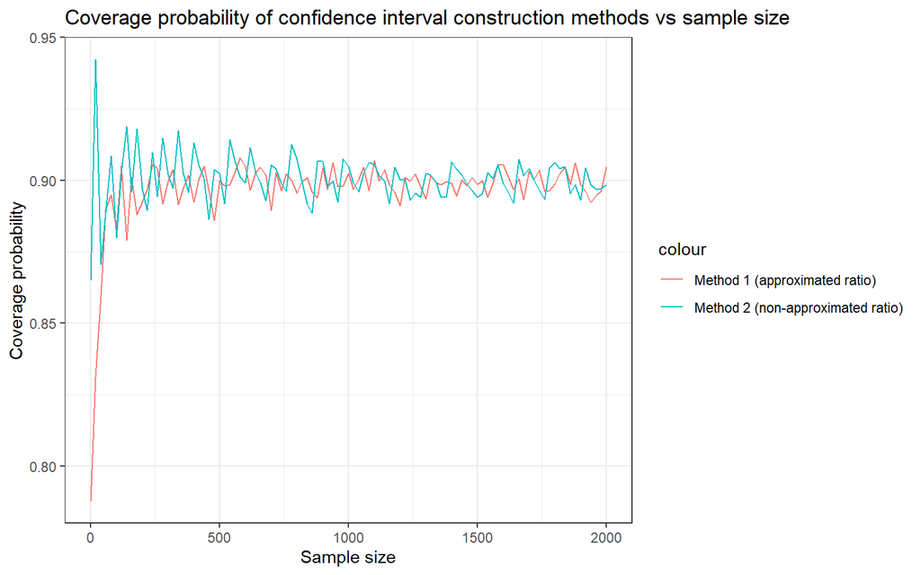

The plot suggests that, for smaller values of $n$, Method 2 has a much higher coverage probability than Method 1. However, as the value of $n$ increases, the difference between these probabilities decreases. Each method performs slightly better than the other for varying large values of $n$. For larger values of $n$, both methods have approximately the same coverage probability.

# 2 3D printer materials prediction

We will estimate the parameters of a Bayesian statistical model of material use in a 3D printer. A CAD (Computer-Aided Design) program is used to estimate how much material will be needed to print the object, i.e. the estimated weight of the object. A plot of the actual weight of objects of different materials, `Actual_Weight`, against their weights estimated by CAD, `CAD_Weight`, is given below.

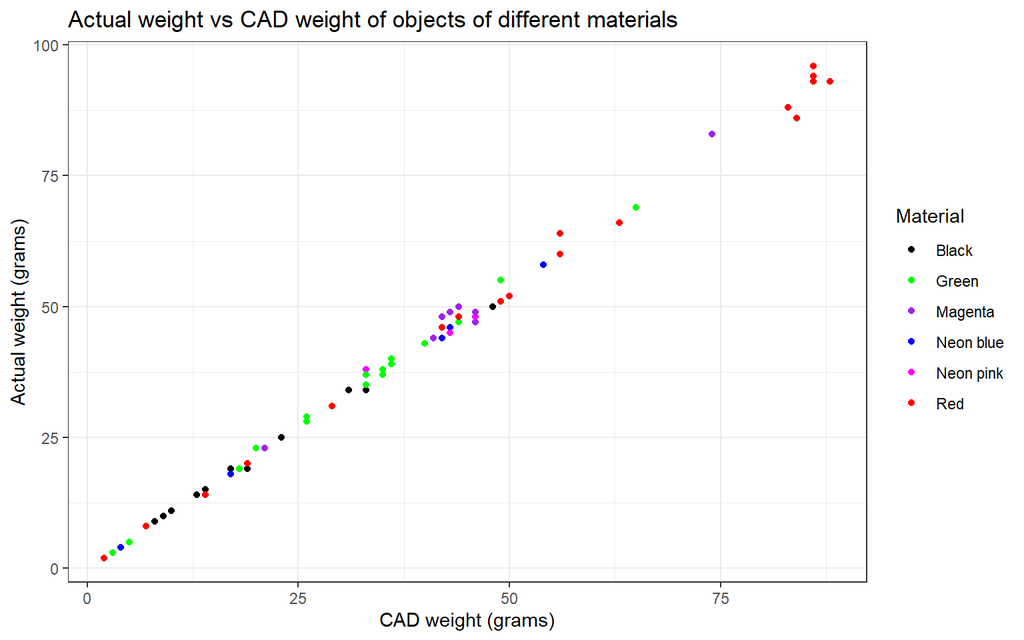

There is both random variation and systematic deviations between the `CAD_weight` and `Actual_Weight` values. We observe that the variability of the data is larger for larger values of `CAD_Weight`. This illustrates a model where the connection between `CAD_Weight` and `Actual_Weight` follows a linear model, and the variance increases with the square of `CAD_Weight`. Let $x_i$ be the CAD weight for observation $i$, and $y_i$ be the corresponding actual weight. Therefore, the model can be defined by

$$y_i \sim \mathsf{Normal}(\beta_1+\beta_2x_i, \beta_3+\beta_4x_i^2).$$

where $\boldsymbol{\gamma} = [\gamma_1, \gamma_2, \gamma_3, \gamma_4]$ are positive parameter values.

## 2.1 Prior density

Since the prior distributions for the four $\theta_i$ parameters are independent, the joint prior density, $p(\boldsymbol{\theta})$, is the product of the four univariate densities. `log_prior_density` defines a function which evaluates the logarithm of the joint prior density

$$\log\left(p(\boldsymbol{\theta})\right) = \log\left(\prod_{i=1}^4p(\theta_i)\right)$$

## 2.2 Observation likelihood

The observation likelihood, $p(\boldsymbol{y}|\boldsymbol{\theta})$, for the model defined above is defined as

$$\begin{aligned}
p(\boldsymbol{y}|\boldsymbol{\theta}) &= \prod_{i=1}^nf(y_i|\boldsymbol{\theta}) \\
&= \prod_{i=1}^n \frac{1}{\sqrt{2\pi(\exp(\theta_3)+\exp(\theta_4)x_i^2)}}\ \exp\left(-\frac{(y_i-(\theta_1+\theta_2x_i))}{2(\exp(\theta_3)+\exp(\theta_4)x_i^2)} \right)
\end{aligned}$$

Therefore, `log_like` defines the observation log-likelihood function as follows

$$\log(p(\boldsymbol{y}|\boldsymbol{\theta})) = \sum_{i=1}^{n}\log\left(\frac{1}{\sqrt{2\pi(\exp(\theta_3)+\exp(\theta_4)x_i^2)}}\ \exp\left(-\frac{(y_i-(\theta_1+\theta_2x_i))}{2(\exp(\theta_3)+\exp(\theta_4)x_i^2)} \right) \right)$$

## 2.3 Posterior density

Applying Bayes’ Formula, the posterior density is given by
$$p(\boldsymbol{\theta}|\boldsymbol{y}) = \frac{p(\boldsymbol{\theta})p(\boldsymbol{y}|\boldsymbol{\theta})}{p(\boldsymbol{y})} \propto p(\boldsymbol{\theta})p(\boldsymbol{y}|\boldsymbol{\theta}).$$

as $p(\boldsymbol{y})$ is a constant with respect to $\boldsymbol{\theta}$.

Therefore, the logarithm of the posterior density, as defined in `log_posterior_density`, is given by

$$\begin{aligned}
\log(p(\boldsymbol{\theta}|\boldsymbol{y})) &\propto \log\left(p(\boldsymbol{\theta})p(\boldsymbol{y}|\boldsymbol{\theta})\right) \\
&= \log(p(\boldsymbol{\theta})) + \log(p(\boldsymbol{y}|\boldsymbol{\theta})),
\end{aligned}$$

up to some unevaluated normalisation constant.

## 2.4 Posterior mode and Gaussian approximation

We will use the function `log_posterior_density`, defined in `code.R`, to evaluate the posterior mode, $\boldsymbol{\mu}$, for $\boldsymbol{\theta}$. We will also evaluate the inverse of the negated Hessian at the mode, $\mathbf{S}$.

Let $\gamma_i = 1$ for $i = 1, 2, 3, 4$. Let the initial values for $\boldsymbol{\theta}$ be $\boldsymbol{\theta}_0 = [0, 1, 0, 0]$. We use `optim()` to evaluate $\boldsymbol{\mu}$ and $\mathbf{S}$, using maximisation rather than minimisation.

```r
# Initialise gamma values
gamma <- c(1, 1, 1, 1)
# Initialise theta values
initial_theta_vals <- c(0, 1, 0, 0)
# Maximise log_posterior_density, optimising over theta
optimise_theta <- optim(
  par = initial_theta_vals,
  fn = log_posterior_density,
  # Arguments for function "fn"
  x = filament1$CAD_Weight,
  y = filament1$Actual_Weight,
  params = gamma,
  # Method of optimisation
  method = "Nelder-Mead",
  # Maximisation, not minimisation
  control = list(fnscale = -1),
  # Evaluate the Hessian
  hessian = TRUE
)
# Evaluate the posterior mode
posterior_mode <- optimise_theta$par
# Evalaute the inverse of the negated Hessian
inv_negated_hessian <- solve(-optimise_theta$hessian)
```

These results show that the posterior mode for $\boldsymbol{\theta}$ is given by
$$\boldsymbol{\mu} = [-0.1008582, 1.0800126, -2.9827638, -6.7584386] \approx [-0.10, 1.08, -2.98, -6.76].$$
The covariance matrix for $\boldsymbol{\theta}$ at $\boldsymbol{\mu}$ is defined by the inverse of the negated Hessian at the posterior mode, $\boldsymbol{\mu}$, given by

$$\boldsymbol{S} = \begin{bmatrix}
0.0082932 & -0.0003430 & 0.0302232 & -0.0042826 \\
-0.0003430 & 0.0000299 & -0.0014917 & 0.0002112 \\
0.0302232 & -0.0014917 & 1.0651007 & -0.1238291 \\
-0.0042826 & 0.0002112 & -0.1238291 & 0.0454224
\end{bmatrix}$$

Therefore, $\tilde{p}(\boldsymbol{\theta}|\boldsymbol{y}) \sim \boldsymbol{\text{Normal}(\mu, S)}$ is a multivariate Normal approximation to the posterior distribution for $\boldsymbol{\theta}$.

## 2.5 Importance sampling function

We define the function `do_importance` to simulate an importance sample for $\boldsymbol{\beta} = [\beta_1, \beta_2, \beta_3, \beta_4]$. We simulate a sample $\mathbf{A} = \left[\mathbf{a}_1, \mathbf{a}_2,....,\mathbf{a}_N\right]$ of size $N$ from the multivariate Normal approximation of the posterior distribution. We then compute *importance weights*, $w_k, \ k=1,....,N$,

$$w_k =\left. \frac{p(\boldsymbol{\theta})p(\boldsymbol{y}|\boldsymbol{\theta})}{\tilde{p}(\boldsymbol{\theta}|\boldsymbol{y})}\right|_{\boldsymbol{\theta} = \boldsymbol{a}_k}$$

We then compute the logarithm of these weights, $\log(w_k)$. We use the `log_sum_exp` function to calculate a normalisation constant, $c = \log\left(\sum_{i=1}^{N}\exp(\log(w_k)\right)$. We compute normalised log importance weights, $\log(\tilde{w}_k) = \log(w_k) - c$, such that $\sum_{i=1}^{N}\exp\left(\log\left(\tilde{w}_k\right)\right)=1$. Finally, since $\boldsymbol{\theta} = [\theta_1, \theta_2, \theta_3, \theta_4] = [\beta_1, \beta_2, \log(\beta_3), \log(\beta_4)]$, we transform the sample values for $\boldsymbol{\theta}$ back to the parameter scale of $\boldsymbol{\beta}$ by taking the exponential of each sample value for $\theta_3$ and $\theta_4$.

## 2.6 Importance sampling

We compute an importance sample of size $N=10000$ using the `do_importance` function.

```r
# Compute importance sample
importance_sample <- do_importance(10000,
  mu = posterior_mode, S = inv_negated_hessian, x = filament1$CAD_Weight, y = filament1$Actual_Weight,
  params = gamma
)
```

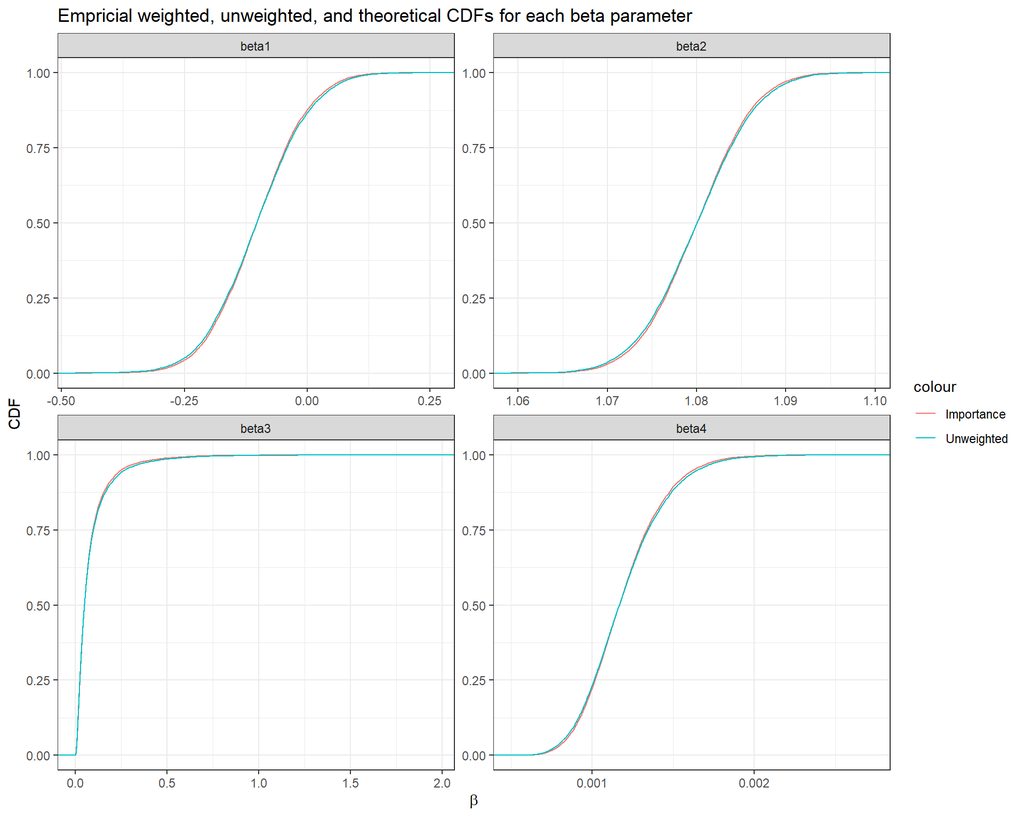

For each $\boldsymbol{\beta}$ parameter, the importance sample and unweighted sample are extremely close. This suggests that, for this model, the Gaussian approximation of the posterior distribution of $\boldsymbol{\theta}=[\beta_1, \beta_2, \log(\beta_3), \log(\beta_4)]$, $\tilde{p}(\boldsymbol{\theta}|\boldsymbol{y}) \sim \boldsymbol{\text{Normal}(\mu, S)}$, is a very good approximation, even before applying importance sampling.

We construct $90\%$ credible intervals for each of the $\boldsymbol{\beta}$ parameters, based on the importance sample.

```r
# Create an empty data frame to store results
beta_intervals <- data.frame(matrix(nrow = 4, ncol = 2))
rownames(beta_intervals) <- c(
  "beta1", "beta2", "beta3",
  "beta4"
)
colnames(beta_intervals) <- c("Lower", "Upper")
# Iterate over each beta parameter
for (i in seq_len(4)) {
  # Construct a 90% credible interval for beta_i
  CI <- make_CI(importance_sample[, i],
    prob = 0.9,
    weights = exp(importance_sample$log_weights)
  )
  # Store the results in the dataframe
  beta_intervals[i, ] <- CI[, ]
}
```

[output not shown]

The 3D printer application models the actual weight of an object, $y_i$, as
$$y_i \sim \mathsf{Normal}(\beta_1+\beta_2x_i, \beta_3+\beta_4x_i^2).$$

It assumes that the error in the CAD software calculation of the weight is proportional to the weight itself. The credible intervals above support this assumption. The credible intervals for $\beta_1$ and $\beta_2$ suggest that the mean, $\beta_1 + \beta_2x_i$, is approximately equivalent to the value of $x_i$, with some slight deviation. This deviation increases as the value of $x_i$ increases, i.e. as the CAD software-calculated weight increases. The credible intervals for $\beta_3$ and $\beta_4$ suggest that the variance increases very slightly as the value of $x_i$ increases, i.e. as the CAD software-calculated weight increases, the variance increases very slightly with the square of this weight. This implies that the error is indeed proportional to the actual weight of an object.

We plot the importance log-weights to see how they depend on the sampled $\boldsymbol{\beta}$-values.

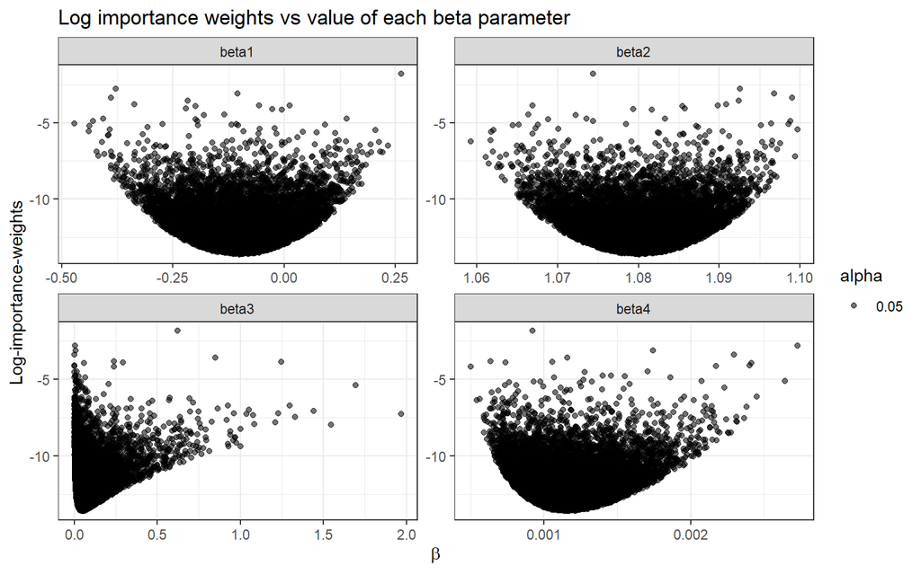

Each of the plots above are quite similar, suggesting that the importance log-weights have the same dependency on each of the $\beta$ parameters. The majority of points in the plots are clustered within the values of the credible intervals for each $\boldsymbol{\beta}$ parameter, with a small number of outliers.

The log-weights are smallest when $\beta_i$ is close to its mean value, $\mu_i$. As the value of $\beta_i$ deviates farther away from its mean, the value of the corresponding log-weight increases. From the sampling method point of view, this is to be expected. The majority of the sampled $\boldsymbol{\beta}$ values would be close to the mean. They would be within their respective credible intervals with probability $90\%$. Therefore, we would expect the outlier $\boldsymbol{\beta}$ values that deviate from these intervals to have a higher weight, as they are far less common.

In conclusion, the importance sampling method is an extremely accurate approximation of the true posterior distribution for this model. Both the unweighted sample and the Gaussian approximation are also very close to the true posterior distribution, and so are excellent approximations. Overall, each of these approximations is a good estimate of the $\boldsymbol{\beta}$ parameters, with the importance sampling method being the most accurate.

# 3 Code appendix

```r
#' Michelle Cleary, s1979093, michellecleary
#' Add your own function definitions at the top of this file.

#' Poisson model confidence interval construction
#' (non-approximated ratio)
#'
#' @param y vector of observations
#' @param alpha percentage level of significance of interval
#'
#' @return (a, b), the confidence interval for lambda

conf_int <- function(y, alpha) {
  # Compute number of observations
  n <- length(y)
  # Compute ybar
  ybar <- mean(y)
  # Compute lambda^hat
  lambda_hat <- ybar
  # Compute the quantiles a and b
  a <- qnorm(alpha / 2)
  b <- qnorm(1 - alpha / 2)
  # Compute the confidence interval
  lower <- max(0, 1 / 2 * (a^2 / n + 2 * lambda_hat + a / n * sqrt(a^2 + 4 * n * lambda_hat)))
  upper <- 1 / 2 * (b^2 / n + 2 * lambda_hat + b / n * sqrt(b^2 + 4 * n * lambda_hat))
  interval <- c(lower, upper)
  interval
}


#' Poisson model confidence interval construction
#' (approximated ratio)
#'
#' @param y vector of observations
#' @param alpha percentage level of significance of interval
#'
#' @return (a, b), the confidence interval for lambda

approx_conf_int <- function(y, alpha) {
  # Compute number of observations
  n <- length(y)
  # Compute yabr
  ybar <- mean(y)
  # Compute lambda^hat
  lambda_hat <- ybar
  # Compute the quantiles a and b
  a <- qnorm(alpha / 2)
  b <- qnorm(1 - alpha / 2)
  # Compute the confidence interval
  lower <- max(0, lambda_hat - b * sqrt(lambda_hat / n))
  upper <- lambda_hat - a * sqrt(lambda_hat / n)
  interval <- c(lower, upper)
  interval
}


#' Log prior density
#'
#' Evaluate the logarithm of the joint prior density p(<U+03B8>)
#' for each parameter in <U+03B8>
#'
#' @param theta theta parameter vector
#' @param params vector of gamma parameters
#'
#'
log_prior_density <- function(theta, params) {
  # Compute the univariate log prior densities p(theta_i), i=1,....,4
  p_theta_1 <- dnorm(theta[1], mean = 0, sd = sqrt(params[1]), log = TRUE)
  p_theta_2 <- dnorm(theta[2], mean = 1, sd = sqrt(params[2]), log = TRUE)
  p_theta_3 <- dlogexp(theta[3], rate = params[3], log = TRUE)
  p_theta_4 <- dlogexp(theta[4], rate = params[4], log = TRUE)
  # Compute the joint prior densities p(theta)
  p_theta <- p_theta_1 + p_theta_2 + p_theta_3 + p_theta_4
  p_theta
}

#' Log-likelihood
#'
#' Evaluate the observation log-likelihood p(y|theta) for the
#' model yi~Normal[beta_1+beta_2*x_i, beta_3+beta_4*x_i^2)]
#'
#' @param theta theta parameter vector
#' @param x CAD weight for observation i
#' @param y actual weight for observation i
#'
#'

log_like <- function(theta, x, y) {
  # Compute the number of observations
  n <- length(x)
  # Initialise the log-likelihood p(y|theta) as 0
  p_y_theta <- 0
  # Iterate over each observation
  for (i in seq_len(n)) {
    # Compute the log-likelihood for observation i
    p_y_i_theta <- dnorm(y[i],
      mean = theta[1] + theta[2] * x[i],
      sd = sqrt(exp(theta[3]) + exp(theta[4]) * x[i]^2), log = TRUE
    )
    # Add this value to the log-likelihood p(y|theta)
    p_y_theta <- p_y_theta + p_y_i_theta
  }
  p_y_theta
}

#' Log posterior density
#'
#' Evaluate the logarithm of the posterior density p(<U+03B8>|y),
#' apart from some unevaluated normalisation constant
#'
#' @param theta theta parameter vector
#' @param x CAD weight for observation i
#' @param y actual weight for observation i
#' @param params vector of gamma parameters
#'
#'
log_posterior_density <- function(theta, x, y, params) {
  # Compute the log of the prior density p(theta)
  p_theta <- log_prior_density(theta, params)
  # Compute the log-likelihood p(y|theta)
  p_y_theta <- log_like(theta, x, y)
  # Compute the log of the posterior density p(theta|y)
  p_theta_y <- p_theta + p_y_theta
  p_theta_y
}

#' Importance sampling function
#'
#' @param N number of samples to generate
#' @param mu mean vector for the importance distribution
#' @param S covariance matrix
#'
#' @return A data frame with 5 columns containing the beta_i
#' samples, for i = 1,...,4, and the normalised
#' log-importance-weights
#'
do_importance <- function(N, mu, S, x, y, params) {
  # Simulate an importance sample for theta
  sample_theta <- rmvnorm(N, mean = mu, sigma = S)
  # Compute the log-weights
  log_weights <- log_prior_density(sample_theta, params) +
    log_like(sample_theta, x, y) -
    dmvnorm(sample_theta, mean = mu, sigma = S, log = TRUE)
  # Compute the normalisation constant
  normalisation_const <- log_sum_exp(log_weights)
  # Subtract the normalisation constant from the log-weights such that sum(exp(log_weights)) = 1
  log_weights <- log_weights - normalisation_const
  # Take the exponential of the sample values for theta_3 and theta_4 as we want an importance sample for beta
  sample_theta[, 3] <- exp(sample_theta[, 3])
  sample_theta[, 4] <- exp(sample_theta[, 4])
  # Create a data frame containing the beta samples and the normalised log-weights
  df <- data.frame(sample_theta, log_weights)
  # Set the column names
  colnames(df) <- c(paste("beta", seq_len(ncol(df) - 1), sep = ""), "log_weights")
  df
}

#' Credible interval construction
#'
#' @param x vector of importance samples
#' @param weights importance weights
#' @param prob intended coverage probability

make_CI <- function(x, prob, weights) {
  # Compute the significance level alpha
  alpha <- 1 - prob
  # Compute the credible interval
  CI <- wquantile(x, probs = c(alpha / 2, 1 - (alpha / 2)), weights = weights)
  data.frame(CI)
}

#' Log-Exponential density
#'
#' Compute the density or log-density for a Log-Exponential (LogExp)
#' distribution
#'
#' @param x vector of quantiles
#' @param rate vector of rates
#' @param log logical; if TRUE, the log-density is returned

dlogexp <- function(x, rate = 1, log = FALSE) {
  result <- log(rate) + x - rate * exp(x)
  if (!log) {
    exp(result)
  }
  result
}

#' Log-Sum-Exp
#'
#' Convenience function for computing log(sum(exp(x))) in a
#' numerically stable manner
#'
#' @param x numerical vector

log_sum_exp <- function(x) {
  max_x <- max(x, na.rm = TRUE)
  max_x + log(sum(exp(x - max_x)))
}


#' Interval coverage estimation
#'
#' @param approx_method a function object taking arguments x and alpha,
#'   returning a 2-element vector.
#' @param non_approx_method a function object taking arguments x and alpha,
#'   returning a 2-element vector.
#' @param N The number of simulation replications to use for the coverage estimate
#' @param alpha 1-alpha is the intended coverage probability
#' @param n The sample size
#' @param lambda The true lambda values for the Poisson(lambda) model
#'
#' @return A 2-element vector, each element a scalar between 0 and 1,
#' estimating the coverage probabilities for the `approx_method` and
#' `non_approx_method` intervals for the given parameters.


estimate_coverage <- function(approx_method,
                              non_approx_method,
                              N = 10000,
                              alpha = 0.1,
                              n = 2,
                              lambda = 3) {
  cover_approx <- 0
  cover_non_approx <- 0
  for (loop in seq_len(N)) {
    y <- rpois(n, lambda)
    ci_approx <- approx_method(y, alpha)
    ci_non_approx <- non_approx_method(y, alpha)
    cover_approx <- cover_approx +
      ((ci_approx[1] <= lambda) && (lambda <= ci_approx[2]))
    cover_non_approx <- cover_non_approx +
      ((ci_non_approx[1] <= lambda) && (lambda <= ci_non_approx[2]))
  }
  c(cover_approx / N, cover_non_approx / N)
}
```